# HW7 Instructions

Author

Data Science 2

```r
library(tidyverse)
library(tidytext)
library(schrute)
library(kableExtra)
library(topicmodels)
```

```r
office <- theoffice
```

# The Office

Let’s continue to work with *The Office* text from the [schrute](https://cran.r-project.org/web/packages/schrute/index.html) package.

# Primary Topics

For each season (not each episode anymore), determine the primary topics for the show using 1) a TF-IDF approach and 2) an LDA approach. You should do at least some cleaning of the data to exclude words that don’t make sense.

#### Data Cleaning:

```r
office2 <- office |>
  group_by(season) |>
  summarize(text = paste(text, collapse = " "))

# Custom stopwords
extra_stopwords <- c("yeah", "hey", "uh", "gonna", "um")

office3 <- office2 |>
  unnest_tokens(word, text) |>
  anti_join(stop_words) |>
  #extra words identified after LDA/TF-IDF
  filter(!word %in% extra_stopwords) |>
  #entirely letters
  filter(str_detect(word, "^[a-z]+$")) |>
  #no sound effects
  filter(!str_detect(word, "(.)\\1{2,}"))
```

*Donovan: This cleaning setup makes sense, especially how you’re using `anti_join(stop_words)` and then adding your own custom stopwords. It’s clear what you’re trying to remove and the filters you used help keep the text consistent.*

#### TF-IDF

```r
#Create Term Freq
office_tf <- office3 |>
  count(season, word) |>
  group_by(season) |>
  mutate(TF = n / sum(n)) |>
  ungroup()

#Doc Freq
office_tf |>
  distinct(season, word) |>
  count(word, sort = TRUE) |>
  rename(DT = n) |>
  head(10)
```

```
# A tibble: 10 × 2
   word          DT
   <chr>      <int>
 1 absolutely     9
 2 account        9
 3 accounting     9
 4 act            9
 5 acting         9
 6 age            9
 7 ago            9
 8 agree          9
 9 ah             9
10 ahead          9
```

```r
#Doc Freq Prop and ITF
office_idf <- office_tf |>
  distinct(season, word) |>
  count(word) |>
  rename(DT = n) |>
  mutate(DF = DT / {office3 |> distinct(season) |> nrow()},
         IDF = 1 / DF,
         logIDF = log(IDF))

#TF-IDF
office_tf_idf <- office_tf |>
  left_join(office_idf, by = "word") |>
  mutate(TFIDF = TF * logIDF)

#Primary Words by Season
office_tf_idf |>
  group_by(season) |>             # group by season
  slice_max(TFIDF, n = 10) |>     # get top 10 words per season
  select(season, word, TFIDF) |>  # keep only the columns you care about
  ungroup()
```

```
# A tibble: 92 × 3
   season word         TFIDF
    <int> <chr>        <dbl>
 1      1 downsizing 0.00555
 2      1 googi      0.00505
 3      1 diversity  0.00449
 4      1 katy       0.00380
 5      1 dupee      0.00353
 6      1 alliance   0.00328
 7      1 purses     0.00303
 8      1 nyuck      0.00252
 9      1 whassup    0.00252
10      1 du         0.00224
# ℹ 82 more rows
```

```r
#Top Word Each Season
#Primary Words by Season
office_tf_idf |>
  group_by(season) |>             # group by season
  slice_max(TFIDF, n = 1) |>     # get top 10 words per season
  select(season, word, TFIDF) |>  # keep only the columns you care about
  ungroup()
```

```
# A tibble: 9 × 3
  season word         TFIDF
   <int> <chr>        <dbl>
1      1 downsizing 0.00555
2      2 dundies    0.00119
3      3 wimowheh   0.00328
4      4 rabies     0.00365
5      5 na         0.00262
6      6 sabre      0.00233
7      7 deangelo   0.00477
8      8 andy       0.00230
9      9 lice       0.00350
```

This is pretty interesting. I’ve watched the show through a few times, and these one word TF-IDF top results do a really good job of capturing the major theme. Season 3 and 5 would require a second look. I know in season3, they sing “In the Jungle” which has severage usages of the word, thus likely skewing the result, given its uniqueness.

*Donovan: I like how you explained the TF-IDF results here. The way you connected the output back to actual moments in the show helps make the results easier to understand. The code for getting the top words by season is also pretty clean and easy to follow.*

#### LDA

```r
#DTM - convert tokenized text into document matrix using cast_dtm
office_dtm <- office3 |>
  count(season, word) |>
  cast_dtm(document = season, term = word, value = n)

#fit model - Using DTM, find unique topics by office season
office_lda <- LDA(office_dtm, k = 3)

#top words - outline the top words by season
office_topics <- tidy(office_lda, matrix = "beta") |>
  mutate(topic = paste0("topic", topic)) |>
  group_by(topic) |>
  slice_max(beta, n = 10) |>
  ungroup()

#table - quick review of topics, term, and beta
office_topics |>
  select(topic, term, beta) |>
  head()
```

```
# A tibble: 6 × 3
  topic  term       beta
  <chr>  <chr>     <dbl>
1 topic1 michael 0.0100
2 topic1 jim     0.00860
3 topic1 dwight  0.00793
4 topic1 time    0.00754
5 topic1 pam     0.00686
6 topic1 people  0.00614
```

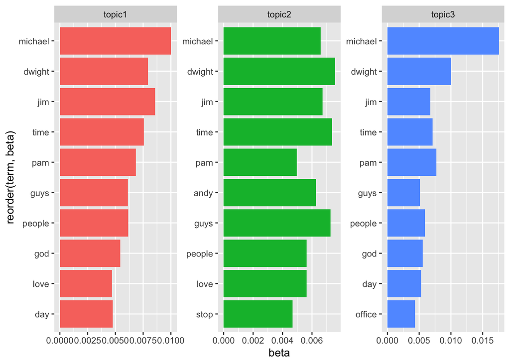

```r
office_topics |>
  ggplot(aes(beta, term |> reorder(beta), fill = topic |> as.factor())) +
  geom_col(show.legend = F) +
  facet_wrap(~topic, scales = "free") +
  scale_y_reordered()
```

I made a subjective decision to not remove the proper nouns. I figured some seasons may have a central theme around a character, like the season Michael left. However, it seems the LDA approach was primarily impacted by the characters. TF-IDF gave extra emphasis to unique words across the seasons, and many proper nouns were common across the seasons. This is not true for LDA.

*Donovan: This explanation of the LDA results is solid. It makes sense how you’re thinking about the topics across seasons, and the way you pulled the top terms using `tidy()` and grouped them is straightforward and works well.*

*Donovan (Suggestion): One thing that could help is adding a few short comments inside the code chunks, especially in the LDA section. For example, briefly explaining what `cast_dtm()` and the LDA model step are doing would make it easier to follow.*

Christ (Response): *Added comments to illustrate what each section of code is doing in my LDA section.*